# ES335_Prerequsite_test

### **1. How many multiplications and additions do you need to perform a matrix multiplication between a (n, k) and (k, m) matrix? Explain.**

For multiplication of any two matrices- A(n,k) , B(k,m), we should take the **inner product of every row of matrix A with every column of matrix B.**

So, for example we take C (n,m) = A(n,k)*B(k,m)

From the above operation, The number of multiplications required for getting one element of C = k

The number of additions required for getting one element of C = k -1

For the entire Matrix Multiplication, we need Total Multiplication operations = Total Number of elements in C X Number of multiplications required for computing a single element in C = nxmxk.

Total Addition operations = Total Number of elements in C X Number of addition operation required for computing a single element in C = nxmx(k-1).

### **2. Write Python code to multiply the above two matrices. Solve using list of lists and then use numpy. Compare the timing of both solutions. Which one is faster? Why?**

**Using list of lists**

```python
n,k = map(int,input("Enter shape of Matrix A ").split())
l,m = map(int,input("Enter shape of Matrix B ").split())
```

```
Enter shape of Matrix A 2 2
Enter shape of Matrix B 2 2
```

```python
if (l != k):
  print("Matrix multiplication is not possible")
else:
  A=[]
  for i in range(n):
    temp = [int(x) for x in input("Enter row  of matrix A").split()]
    A.append(temp)
  B =[]
  for j in range(m):
    temp = [int(x) for x in input("Enter row  of matrix B").split()]
    B.append(temp)
```

```
Enter row  of matrix A1 0
Enter row  of matrix A0 1
Enter row  of matrix B2 3
Enter row  of matrix B4 5
```

```python
%%time
C=[]
for i in range (n):
  temp =[]
  for j in range(m):
    s =0
    for l in range(k):
      s+= A[i][l]*B[l][j]
    temp.append(s)
  C.append(temp)
print(C)
```

```
[[2, 3], [4, 5]]
CPU times: user 177 µs, sys: 0 ns, total: 177 µs
Wall time: 184 µs
```

**Using numpy**

```python
import numpy as np
np_matrix_A = np.array([np.array(x) for x in A])
np_matrix_B = np.array([np.array(x) for x in B])
np_matrix_A, np_matrix_B
```

```
(array([[1, 0],
        [0, 1]]),
 array([[2, 3],
        [4, 5]]))
```

```python
%%time
np.matmul(A,B)
```

```
CPU times: user 102 µs, sys: 0 ns, total: 102 µs
Wall time: 107 µs
```

```
array([[2, 3],
       [4, 5]])
```

When we compare the execution times of both lists of lists method and numpy matrix multiplication, Numpy method performs matrix multiplications quicker. This is because in numpy matrix multiplication are carried out in a vectorized and parralell manner. Moreover the numpy methods are optimized while the lists of lists which I have wrote is a brute force approach

### **3. Finding the highest element in a list requires one pass of the array. Finding the second highest element requires 2 passes of the the array. Using this method, what is the time complexity of finding the median of the array? Can you suggest a better method? Can you implement both these methods in Python and compare against numpy.median routine in terms of time?**

**Finding median of array without numpy - Time Complexity O($n^{2}$)**

```python
%%time
array = [12,3,5,65,7,8,9]
n = len(array)
for i in range(n//2 +1):
  key = i
  val = array[i]
  for j in range(i+1,n):
    if(val > array[j] ):
      key = j
      val = array[j]
  array[i],array[key] = array[key] , array[i]

print("Median :", array[n//2] )
```

```
Median : 8
CPU times: user 2.72 ms, sys: 0 ns, total: 2.72 ms
Wall time: 6.76 ms
```

**Finding median of array without numpy (Better method) - Time Complexity O($nlog(n)$)**

```python
%%time
array.sort()
print(f"Median : {array[n//2]}")
```

```
Median : 8
CPU times: user 710 µs, sys: 0 ns, total: 710 µs
Wall time: 656 µs
```

**Finding median of array using numpy**

```python
%%time
array = np.array(array)
print(np.median(array))
```

```
8.0
CPU times: user 28.6 ms, sys: 0 ns, total: 28.6 ms
Wall time: 76.9 ms
```

**From the total time taken perspective, sorting and picking the middle element** **outperforms** `np.median()` method

### **4. What is the gradient of the following function with respect to x and y?**

$x^{2}y + y^{3}sin(x)$

The gradient of the function w.r.t x is $f_x = 2xy+y^{3}cos(x)$

The gradient of the function w.r.t y is $f_x = x^{2}+3y^{2}sin(x)$

### **5. Use JAX to confirm the gradient evaluated by your method matches the analytical solution corresponding to a few random values of x and y**

```python
import jax.numpy as np
from jax import grad

def f(x, y):
    return (x**2)*y +(y**3)*np.sin(x)

x_value = [0.0,float(np.pi)/2,float(np.pi),1.5*float(np.pi),2*float(np.pi)]
y_value = [0.0,1.0,2.0,3.0,4.0]

for i in range(5):
  df_dx = grad(f, argnums=0)
  df_dy = grad(f, argnums=1)
  gradient_at_point_x = df_dx(x_value[i], y_value[i])
  gradient_at_point_y = df_dy(x_value[i], y_value[i])
  df_dx = gradient_at_point_x
  df_dy = gradient_at_point_y
  dx = 2*x_value[i]*y_value[i] +(y_value[i]**3)*np.cos(x_value[i])
  dy = (x_value[i]**2)+ 3*(y_value[i]**2)*np.sin(x_value[i])

  print(f"The partial derivative of f with respect to x at ({x_value[i]}, {y_value[i]}) : ")
  print(f"Using JAX : {df_dx} , Using normal calculation : {dx} ")
  print(f"The partial derivative of f with respect to y at ({x_value[i]}, {y_value[i]}) :")
  print(f"Using JAX : {df_dy} , Using normal calculation : {dy} ")
```

```
The partial derivative of f with respect to x at (0.0, 0.0) :
Using JAX : 0.0 , Using normal calculation : 0.0
The partial derivative of f with respect to y at (0.0, 0.0) :
Using JAX : 0.0 , Using normal calculation : 0.0
The partial derivative of f with respect to x at (1.5707963267948966, 1.0) :
Using JAX : 3.1415927410125732 , Using normal calculation : 3.1415927410125732
The partial derivative of f with respect to y at (1.5707963267948966, 1.0) :
Using JAX : 5.467401027679443 , Using normal calculation : 5.467401027679443
The partial derivative of f with respect to x at (3.141592653589793, 2.0) :
Using JAX : 4.566370964050293 , Using normal calculation : 4.566370964050293
The partial derivative of f with respect to y at (3.141592653589793, 2.0) :
Using JAX : 9.869603157043457 , Using normal calculation : 9.869603157043457
The partial derivative of f with respect to x at (4.71238898038469, 3.0) :
Using JAX : 28.274333953857422 , Using normal calculation : 28.274333953857422
The partial derivative of f with respect to y at (4.71238898038469, 3.0) :
Using JAX : -4.793390274047852 , Using normal calculation : -4.793390274047852
The partial derivative of f with respect to x at (6.283185307179586, 4.0) :
Using JAX : 114.26548767089844 , Using normal calculation : 114.26548767089844
The partial derivative of f with respect to y at (6.283185307179586, 4.0) :
Using JAX : 39.478424072265625 , Using normal calculation : 39.478424072265625
```

### **6. Use sympy to confirm that you obtain the same gradient analytically.**

```python
from sympy import symbols, diff,sin
x, y = symbols('x y')
f = (x**2)*y +(y**3)*sin(x)
partial_derivative_x = diff(f, x)
partial_derivative_y = diff(f, y)
print("The partial derivative of f(x, y) with respect to x is:", partial_derivative_x)
print("The partial derivative of f(x, y) with respect to y is:", partial_derivative_y)
```

```
The partial derivative of f(x, y) with respect to x is: 2*x*y + y**3*cos(x)
The partial derivative of f(x, y) with respect to y is: x**2 + 3*y**2*sin(x)
```

### **7. Create a Python nested dictionary to represent hierarchical information. We want to store record of students and their marks. Something like:**

1. 2022
2. Branch 1
3. Roll Number: 1, Name: N, Marks:
4. Maths: 100, English: 70 …
5. Branch 2
6. 2023
7. Branch 1
8. Branch 2
9. 2024
10. Branch 1
11. Branch 2
12. 2025
13. Branch 1
14. Branch 2

```python
student_record = {
    "2022":{
        "Branch1":{
            "Roll Number":1,
            "Name": "N",
            "Marks":{
                "Maths": 100,
                "English": 70
            }

        },
        "Branch2":{}
    },
  "2023": {
      "Branch1":{},
      "Branch2":{}
  },
    "2024": {
      "Branch1":{},
      "Branch2":{}
  },
  "2025": {
      "Branch1":{},
      "Branch2":{}
  },

}
student_record
```

```
{'2022': {'Branch1': {'Roll Number': 1,
   'Name': 'N',
   'Marks': {'Maths': 100, 'English': 70}},
  'Branch2': {}},
 '2023': {'Branch1': {}, 'Branch2': {}},
 '2024': {'Branch1': {}, 'Branch2': {}},
 '2025': {'Branch1': {}, 'Branch2': {}}}
```

### **8. Store the same information using Python classes. We have an overall database which is a list of year objects. Each year contains a list of branches. Each branch contains a list of students. Each student has some properties like name, roll number and has marks in some subjects.**

```python
class student:
  def __init__(self,name,rollno,marks):
    self.name = name
    self.rollno = rollno
    self.marks=marks
  def get_student(self):
    print(self.name,self.rollno,self.marks)

class branch:
  def __init__(self,branch,stud_info):
    self.branch = branch
    self.stud_info = stud_info
  def get_branch(self):
    print(self.branch,self.stud_info)

class year:
  def __init__(self,year,branches):
    self.year = year
    self.branches = branches
  def get_year(self):
    print(self.year,self.branches)
```

### **9. Using matplotlib plot the following functions on the domain: x = 0.5 to 100.0 in steps of 0.5.**

```python
import matplotlib.pyplot as plt
x = np.arange(start = 0.5,stop = 100.5 , step = 0.5)
x
```

```
array([  0.5,   1. ,   1.5,   2. ,   2.5,   3. ,   3.5,   4. ,   4.5,
         5. ,   5.5,   6. ,   6.5,   7. ,   7.5,   8. ,   8.5,   9. ,
         9.5,  10. ,  10.5,  11. ,  11.5,  12. ,  12.5,  13. ,  13.5,
        14. ,  14.5,  15. ,  15.5,  16. ,  16.5,  17. ,  17.5,  18. ,
        18.5,  19. ,  19.5,  20. ,  20.5,  21. ,  21.5,  22. ,  22.5,
        23. ,  23.5,  24. ,  24.5,  25. ,  25.5,  26. ,  26.5,  27. ,
        27.5,  28. ,  28.5,  29. ,  29.5,  30. ,  30.5,  31. ,  31.5,
        32. ,  32.5,  33. ,  33.5,  34. ,  34.5,  35. ,  35.5,  36. ,
        36.5,  37. ,  37.5,  38. ,  38.5,  39. ,  39.5,  40. ,  40.5,
        41. ,  41.5,  42. ,  42.5,  43. ,  43.5,  44. ,  44.5,  45. ,
        45.5,  46. ,  46.5,  47. ,  47.5,  48. ,  48.5,  49. ,  49.5,
        50. ,  50.5,  51. ,  51.5,  52. ,  52.5,  53. ,  53.5,  54. ,
        54.5,  55. ,  55.5,  56. ,  56.5,  57. ,  57.5,  58. ,  58.5,
        59. ,  59.5,  60. ,  60.5,  61. ,  61.5,  62. ,  62.5,  63. ,
        63.5,  64. ,  64.5,  65. ,  65.5,  66. ,  66.5,  67. ,  67.5,
        68. ,  68.5,  69. ,  69.5,  70. ,  70.5,  71. ,  71.5,  72. ,
        72.5,  73. ,  73.5,  74. ,  74.5,  75. ,  75.5,  76. ,  76.5,
        77. ,  77.5,  78. ,  78.5,  79. ,  79.5,  80. ,  80.5,  81. ,
        81.5,  82. ,  82.5,  83. ,  83.5,  84. ,  84.5,  85. ,  85.5,
        86. ,  86.5,  87. ,  87.5,  88. ,  88.5,  89. ,  89.5,  90. ,
        90.5,  91. ,  91.5,  92. ,  92.5,  93. ,  93.5,  94. ,  94.5,
        95. ,  95.5,  96. ,  96.5,  97. ,  97.5,  98. ,  98.5,  99. ,
        99.5, 100. ])
```

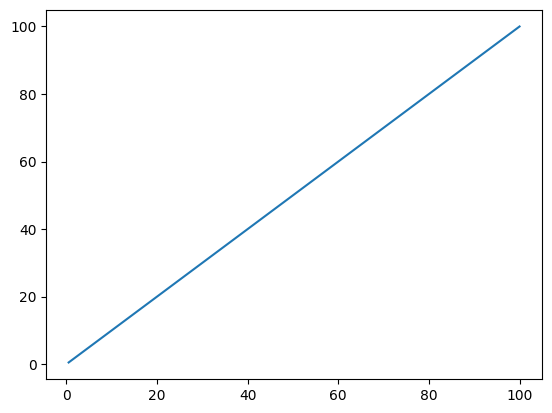

```python
## y =x
plt.plot(x,x)
```

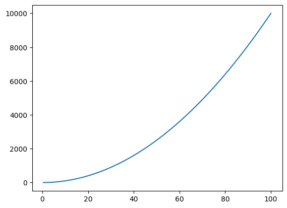

```python
## y = x**2
plt.plot(x,x**2)
```

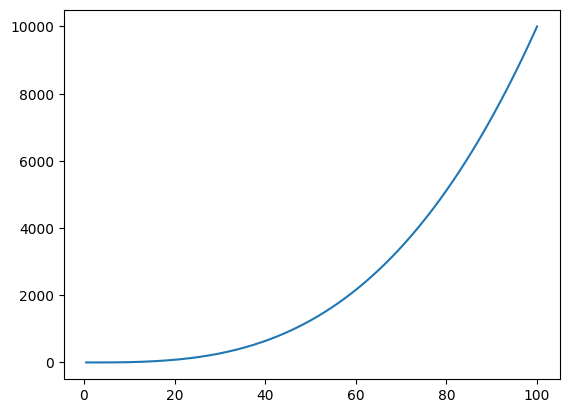

```python
## y =(x**3)/100
plt.plot(x,(x**3)/100)
```

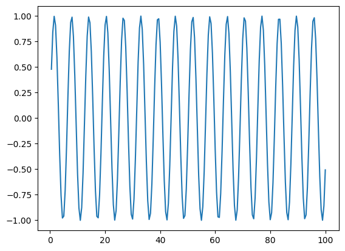

```python
## y = sin(x)
plt.plot(x,np.sin(x))
```

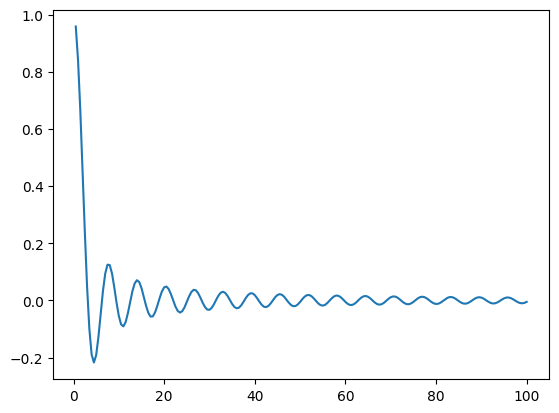

```python
## y = sin(x)/x
plt.plot(x,np.sin(x)/x)
```

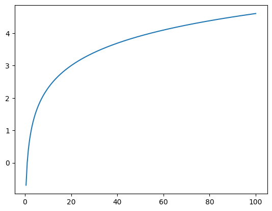

```python
## y = log(x)
plt.plot(x,np.log(x))
```

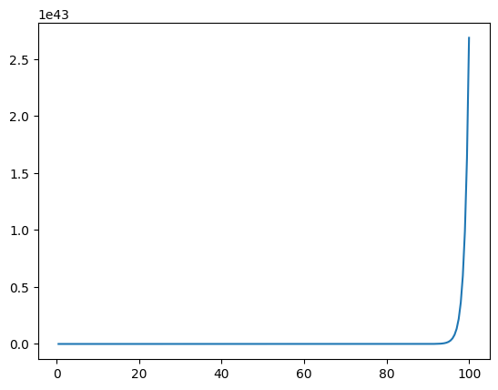

```python
## y = exp(x)
plt.plot(x,np.exp(x))
```

### **10. Using numpy generate a matrix of size 20X5 containing random numbers drawn uniformly from the range of 1 to 2.Using Pandas create a dataframe out of this matrix. Name the columns of the dataframe as “a”, “b”, “c”, “d”, “e”. Find the column with the highest standard deviation. Find the row with the lowest mean.**

```python
import pandas as pd
df_array = np.random.uniform(low = 1, high = 2, size = (20,5))
df = pd.DataFrame(df_array, columns =['a','b','c','d','e'] )
df
```

|  | a | b | c | d | e |
| --- | --- | --- | --- | --- | --- |
| 0 | 1.700266 | 1.782456 | 1.804026 | 1.877974 | 1.649456 |
| 1 | 1.605993 | 1.062938 | 1.146215 | 1.455052 | 1.269735 |
| 2 | 1.430258 | 1.057151 | 1.073516 | 1.762904 | 1.178405 |
| 3 | 1.140596 | 1.345749 | 1.016913 | 1.285500 | 1.652632 |
| 4 | 1.527097 | 1.763608 | 1.431032 | 1.480158 | 1.814483 |
| 5 | 1.509310 | 1.127484 | 1.192906 | 1.100964 | 1.618285 |
| 6 | 1.548663 | 1.876699 | 1.439261 | 1.363835 | 1.222402 |
| 7 | 1.960448 | 1.733836 | 1.867150 | 1.504074 | 1.919658 |
| 8 | 1.568565 | 1.580020 | 1.389941 | 1.532448 | 1.884639 |
| 9 | 1.175313 | 1.018085 | 1.438311 | 1.757583 | 1.481955 |
| 10 | 1.878904 | 1.952647 | 1.193417 | 1.752563 | 1.063076 |
| 11 | 1.496085 | 1.604196 | 1.767557 | 1.583447 | 1.085633 |
| 12 | 1.688076 | 1.245517 | 1.525750 | 1.229154 | 1.534990 |
| 13 | 1.593540 | 1.776997 | 1.703076 | 1.490896 | 1.880569 |
| 14 | 1.510994 | 1.964146 | 1.570526 | 1.600144 | 1.384002 |
| 15 | 1.147574 | 1.592324 | 1.822080 | 1.982967 | 1.903991 |
| 16 | 1.111793 | 1.519565 | 1.961337 | 1.747209 | 1.304352 |
| 17 | 1.600252 | 1.165538 | 1.675483 | 1.130229 | 1.375753 |
| 18 | 1.396536 | 1.866462 | 1.455821 | 1.414400 | 1.038845 |
| 19 | 1.837339 | 1.104386 | 1.747640 | 1.478508 | 1.062427 |

```python
df.describe()
```

|  | a | b | c | d | e |
| --- | --- | --- | --- | --- | --- |
| count | 20.000000 | 20.000000 | 20.000000 | 20.000000 | 20.000000 |
| mean | 1.521380 | 1.506990 | 1.511098 | 1.526501 | 1.466264 |
| std | 0.240487 | 0.333834 | 0.281627 | 0.238930 | 0.310926 |
| min | 1.111793 | 1.018085 | 1.016913 | 1.100964 | 1.038845 |
| 25% | 1.421827 | 1.156025 | 1.340810 | 1.401759 | 1.211403 |
| 50% | 1.537880 | 1.586172 | 1.490785 | 1.497485 | 1.432979 |
| 75% | 1.626514 | 1.778362 | 1.752620 | 1.748548 | 1.693094 |
| max | 1.960448 | 1.964146 | 1.961337 | 1.982967 | 1.919658 |

```python
col_std = df.std()
col_id_std = col_std.idxmax()
print("Column with highest standard deviation: ", col_id_std)
```

```
Column with highest standard deviation:  b
```

```python
col_mean = df.mean()
col_id_mean = col_mean.idxmin()
print("Column with lowest mean: ", col_id_mean)
```

```
Column with lowest mean:  e
```

### **11. Add a new column to the dataframe called “f” which is the sum of the columns “a”, “b”, “c”, “d”, “e”. Create another column called “g”. The value in the column “g” should be “LT8” if the value in the column “f” is less than 8 and “GT8” otherwise. Find the number of rows in the dataframe where the value in the column “g” is “LT8”. Find the standard deviation of the column “f” for the rows where the value in the column “g” is “LT8” and “GT8” respectively.**

```python
df['f']= df.sum(axis =1 )
df['g'] = "GT8"
df.loc[df["f"]<8, "g"] = "LT8"
df
```

|  | a | b | c | d | e | f | g |
| --- | --- | --- | --- | --- | --- | --- | --- |
| 0 | 1.700266 | 1.782456 | 1.804026 | 1.877974 | 1.649456 | 8.814177 | GT8 |
| 1 | 1.605993 | 1.062938 | 1.146215 | 1.455052 | 1.269735 | 6.539933 | LT8 |
| 2 | 1.430258 | 1.057151 | 1.073516 | 1.762904 | 1.178405 | 6.502234 | LT8 |
| 3 | 1.140596 | 1.345749 | 1.016913 | 1.285500 | 1.652632 | 6.441390 | LT8 |
| 4 | 1.527097 | 1.763608 | 1.431032 | 1.480158 | 1.814483 | 8.016378 | GT8 |
| 5 | 1.509310 | 1.127484 | 1.192906 | 1.100964 | 1.618285 | 6.548950 | LT8 |
| 6 | 1.548663 | 1.876699 | 1.439261 | 1.363835 | 1.222402 | 7.450860 | LT8 |
| 7 | 1.960448 | 1.733836 | 1.867150 | 1.504074 | 1.919658 | 8.985166 | GT8 |
| 8 | 1.568565 | 1.580020 | 1.389941 | 1.532448 | 1.884639 | 7.955612 | LT8 |
| 9 | 1.175313 | 1.018085 | 1.438311 | 1.757583 | 1.481955 | 6.871247 | LT8 |
| 10 | 1.878904 | 1.952647 | 1.193417 | 1.752563 | 1.063076 | 7.840607 | LT8 |
| 11 | 1.496085 | 1.604196 | 1.767557 | 1.583447 | 1.085633 | 7.536918 | LT8 |
| 12 | 1.688076 | 1.245517 | 1.525750 | 1.229154 | 1.534990 | 7.223487 | LT8 |
| 13 | 1.593540 | 1.776997 | 1.703076 | 1.490896 | 1.880569 | 8.445077 | GT8 |
| 14 | 1.510994 | 1.964146 | 1.570526 | 1.600144 | 1.384002 | 8.029813 | GT8 |
| 15 | 1.147574 | 1.592324 | 1.822080 | 1.982967 | 1.903991 | 8.448936 | GT8 |
| 16 | 1.111793 | 1.519565 | 1.961337 | 1.747209 | 1.304352 | 7.644255 | LT8 |
| 17 | 1.600252 | 1.165538 | 1.675483 | 1.130229 | 1.375753 | 6.947254 | LT8 |
| 18 | 1.396536 | 1.866462 | 1.455821 | 1.414400 | 1.038845 | 7.172064 | LT8 |
| 19 | 1.837339 | 1.104386 | 1.747640 | 1.478508 | 1.062427 | 7.230300 | LT8 |

### **12. Write a small piece of code to explain broadcasting in numpy.**

```python
W = np.random.rand(3,5)
x = np.random.rand(5,3)
b = 100
print("W : ",W)
print("X : ",x)

y = np.matmul(W,x)+b ## Brodcasting happens here
print("Result y : ",y)
```

```
W :  [[0.34909078 0.13539894 0.56278331 0.63956333 0.75453219]
 [0.86741467 0.163703   0.11102227 0.81883191 0.67876924]
 [0.35069963 0.71833735 0.74627687 0.8396518  0.71897204]]
X :  [[0.22276688 0.67333303 0.46951573]
 [0.73192901 0.40434399 0.16169571]
 [0.83707393 0.48816652 0.9365602 ]
 [0.27758402 0.18366309 0.9062083 ]
 [0.4627782  0.20841805 0.60770964]]
Result y :  [[101.17467312 100.83925637 101.75099157]
 [100.94739835 100.99630559 101.69224083]
 [101.79438364 101.19496021 102.17756994]]
```

### **13. Write a function to compute the argmin of a numpy array. The function should take a numpy array as input and return the index of the minimum element. You can use the np.argmin function to verify your solution.**

**Finding argmin of numpy array**

```python
array = np.random.rand(100)
array
```

```
array([8.52705788e-01, 5.24748040e-01, 2.54713161e-01, 1.35907011e-01,
       2.85929940e-01, 7.57763525e-01, 8.73276398e-01, 4.59391078e-01,
       3.97168787e-02, 1.17611153e-03, 4.39285202e-01, 6.23574898e-01,
       4.42282916e-01, 7.27079745e-02, 2.01477302e-01, 6.05948037e-01,
       9.63437421e-01, 1.37887876e-01, 1.51155669e-01, 5.42904002e-01,
       3.14659757e-01, 4.93148501e-01, 9.00196738e-01, 8.11679283e-01,
       1.26398113e-01, 3.21281962e-01, 5.91596836e-01, 6.59565673e-01,
       4.21834078e-01, 8.57997842e-01, 9.94040411e-02, 6.89657794e-01,
       4.70729094e-01, 9.41207817e-01, 7.37087395e-01, 8.70983182e-01,
       7.62307143e-01, 8.80141869e-02, 6.22358114e-01, 2.34196886e-01,
       5.34628372e-01, 6.16058685e-02, 1.84278765e-01, 8.17530569e-04,
       4.64762661e-01, 6.57928373e-04, 5.95089189e-01, 7.67382343e-01,
       1.08345941e-02, 6.91815796e-01, 2.08711610e-01, 1.70635095e-01,
       9.59952399e-01, 8.14418119e-01, 9.93497797e-01, 8.54128324e-01,
       7.35340790e-01, 6.26678575e-01, 2.00712795e-01, 6.66224477e-01,
       3.68030222e-01, 8.56986290e-01, 3.95171518e-01, 4.06540215e-01,
       1.39762001e-01, 5.22660092e-01, 1.77891226e-01, 1.55952763e-01,
       1.26413903e-01, 4.21269579e-01, 2.38698168e-01, 5.49821238e-01,
       1.01263857e-02, 7.39424994e-01, 4.30536968e-01, 7.35219504e-01,
       9.31571767e-01, 4.06896380e-01, 9.08489849e-03, 1.49141092e-01,
       4.96876002e-01, 2.98634175e-02, 6.70765434e-01, 6.59331712e-01,
       5.79894799e-01, 4.84770816e-01, 8.04499321e-01, 3.68198207e-01,
       1.68482423e-01, 1.03512650e-01, 8.08391179e-01, 5.94082811e-01,
       8.70228267e-01, 9.38066222e-01, 6.12284513e-01, 2.10144150e-01,
       8.83259307e-01, 5.14327711e-01, 2.47042730e-01, 3.20730072e-01])
```

```python
min_ele = 0
for i in range(1,100):
  if(array[min_ele] > array[i]):
    min_ele = i
print("Index of minimum element",min_ele)
```

```
Index of minimum element 45
```

```python
np.argmin(array)
```

```
45
```